# Risk Factor Analysis

## Outcome Variable

**Outcome Variable:** ever_sstunted

## Predictor Variables

**Intervention Variable:** feducyrs

**Adjustment Set:**

- arm
- W_mage
- meducyrs
- hhwealth_quart
- W_mhtcm
- W_mwtkg
- W_mbmi
- W_gagebrth
- W_birthwt
- W_birthlen
- single
- delta_W_mage
- delta_meducyrs
- delta_hhwealth_quart
- delta_W_mhtcm
- delta_W_mwtkg
- delta_W_mbmi
- delta_W_gagebrth
- delta_W_birthwt
- delta_W_birthlen
- delta_single

## Stratifying Variables

The analysis was stratified on these variable(s):

- agecat
- studyid
- country

## Data Summary

| agecat | studyid | country | feducyrs | ever_sstunted | n_cell | n |
| --- | --- | --- | --- | --- | --- | --- |
| 0-24 months | COHORTS | GUATEMALA | High | 0 | 128 | 1250 |
| 0-24 months | COHORTS | GUATEMALA | High | 1 | 106 | 1250 |
| 0-24 months | COHORTS | GUATEMALA | Low | 0 | 294 | 1250 |
| 0-24 months | COHORTS | GUATEMALA | Low | 1 | 273 | 1250 |
| 0-24 months | COHORTS | GUATEMALA | Medium | 0 | 237 | 1250 |
| 0-24 months | COHORTS | GUATEMALA | Medium | 1 | 212 | 1250 |
| 0-24 months | COHORTS | INDIA | High | 0 | 525 | 1447 |
| 0-24 months | COHORTS | INDIA | High | 1 | 42 | 1447 |
| 0-24 months | COHORTS | INDIA | Low | 0 | 397 | 1447 |
| 0-24 months | COHORTS | INDIA | Low | 1 | 75 | 1447 |
| 0-24 months | COHORTS | INDIA | Medium | 0 | 365 | 1447 |
| 0-24 months | COHORTS | INDIA | Medium | 1 | 43 | 1447 |
| 0-24 months | COHORTS | PHILIPPINES | High | 0 | 794 | 2880 |
| 0-24 months | COHORTS | PHILIPPINES | High | 1 | 237 | 2880 |
| 0-24 months | COHORTS | PHILIPPINES | Low | 0 | 424 | 2880 |
| 0-24 months | COHORTS | PHILIPPINES | Low | 1 | 404 | 2880 |
| 0-24 months | COHORTS | PHILIPPINES | Medium | 0 | 625 | 2880 |
| 0-24 months | COHORTS | PHILIPPINES | Medium | 1 | 396 | 2880 |
| 0-24 months | GMS-Nepal | NEPAL | High | 0 | 135 | 696 |
| 0-24 months | GMS-Nepal | NEPAL | High | 1 | 38 | 696 |
| 0-24 months | GMS-Nepal | NEPAL | Low | 0 | 217 | 696 |
| 0-24 months | GMS-Nepal | NEPAL | Low | 1 | 79 | 696 |
| 0-24 months | GMS-Nepal | NEPAL | Medium | 0 | 175 | 696 |
| 0-24 months | GMS-Nepal | NEPAL | Medium | 1 | 52 | 696 |
| 0-24 months | JiVitA-3 | BANGLADESH | High | 0 | 5711 | 26233 |
| 0-24 months | JiVitA-3 | BANGLADESH | High | 1 | 793 | 26233 |
| 0-24 months | JiVitA-3 | BANGLADESH | Low | 0 | 8589 | 26233 |
| 0-24 months | JiVitA-3 | BANGLADESH | Low | 1 | 2196 | 26233 |
| 0-24 months | JiVitA-3 | BANGLADESH | Medium | 0 | 7136 | 26233 |
| 0-24 months | JiVitA-3 | BANGLADESH | Medium | 1 | 1808 | 26233 |

[output cut: 210 more lines]

The following strata were considered:

- agecat: 0-24 months, studyid: COHORTS, country: GUATEMALA
- agecat: 0-24 months, studyid: COHORTS, country: INDIA
- agecat: 0-24 months, studyid: COHORTS, country: PHILIPPINES
- agecat: 0-24 months, studyid: GMS-Nepal, country: NEPAL
- agecat: 0-24 months, studyid: JiVitA-3, country: BANGLADESH
- agecat: 0-24 months, studyid: JiVitA-4, country: BANGLADESH
- agecat: 0-24 months, studyid: LCNI-5, country: MALAWI
- agecat: 0-24 months, studyid: MAL-ED, country: BANGLADESH
- agecat: 0-24 months, studyid: MAL-ED, country: INDIA
- agecat: 0-24 months, studyid: MAL-ED, country: NEPAL
- agecat: 0-24 months, studyid: MAL-ED, country: PERU
- agecat: 0-24 months, studyid: MAL-ED, country: SOUTH AFRICA
- agecat: 0-24 months, studyid: MAL-ED, country: TANZANIA, UNITED REPUBLIC OF
- agecat: 0-24 months, studyid: NIH-Crypto, country: BANGLADESH
- agecat: 0-24 months, studyid: PROBIT, country: BELARUS
- agecat: 0-24 months, studyid: PROVIDE, country: BANGLADESH
- agecat: 0-24 months, studyid: SAS-CompFeed, country: INDIA
- agecat: 0-24 months, studyid: SAS-FoodSuppl, country: INDIA
- agecat: 0-24 months, studyid: TanzaniaChild2, country: TANZANIA, UNITED REPUBLIC OF
- agecat: 0-24 months, studyid: ZVITAMBO, country: ZIMBABWE
- agecat: 0-6 months, studyid: COHORTS, country: GUATEMALA
- agecat: 0-6 months, studyid: COHORTS, country: INDIA
- agecat: 0-6 months, studyid: COHORTS, country: PHILIPPINES
- agecat: 0-6 months, studyid: GMS-Nepal, country: NEPAL
- agecat: 0-6 months, studyid: JiVitA-3, country: BANGLADESH
- agecat: 0-6 months, studyid: JiVitA-4, country: BANGLADESH
- agecat: 0-6 months, studyid: LCNI-5, country: MALAWI
- agecat: 0-6 months, studyid: MAL-ED, country: BANGLADESH
- agecat: 0-6 months, studyid: MAL-ED, country: INDIA
- agecat: 0-6 months, studyid: MAL-ED, country: NEPAL
- agecat: 0-6 months, studyid: MAL-ED, country: PERU
- agecat: 0-6 months, studyid: MAL-ED, country: SOUTH AFRICA
- agecat: 0-6 months, studyid: MAL-ED, country: TANZANIA, UNITED REPUBLIC OF
- agecat: 0-6 months, studyid: NIH-Crypto, country: BANGLADESH
- agecat: 0-6 months, studyid: PROBIT, country: BELARUS
- agecat: 0-6 months, studyid: PROVIDE, country: BANGLADESH
- agecat: 0-6 months, studyid: SAS-CompFeed, country: INDIA
- agecat: 0-6 months, studyid: SAS-FoodSuppl, country: INDIA
- agecat: 0-6 months, studyid: TanzaniaChild2, country: TANZANIA, UNITED REPUBLIC OF
- agecat: 0-6 months, studyid: ZVITAMBO, country: ZIMBABWE

### Dropped Strata

Some strata were dropped due to rare outcomes:

- agecat: 0-24 months, studyid: MAL-ED, country: NEPAL
- agecat: 0-6 months, studyid: LCNI-5, country: MALAWI
- agecat: 0-6 months, studyid: MAL-ED, country: BANGLADESH
- agecat: 0-6 months, studyid: MAL-ED, country: INDIA
- agecat: 0-6 months, studyid: MAL-ED, country: NEPAL
- agecat: 0-6 months, studyid: MAL-ED, country: SOUTH AFRICA
- agecat: 0-6 months, studyid: MAL-ED, country: TANZANIA, UNITED REPUBLIC OF

## Methods Detail

We’re interested in the causal parameters $E[Y_a]$ for all values of $a \in \mathcal{A}$. These parameters represent the mean outcome if, possibly contrary to fact, we intervened to set all units to have $A=a$. Under the randomization and positivity assumptions, these are identified by the statistical parameters $\psi_a=E_W[E_{Y|A,W}(Y|A=a,W)]$. In addition, we’re interested in the mean of $Y$, $E[Y]$ under no intervention (the observed mean). We will estimate these parameters by using SuperLearner to fit the relevant likelihood factors – $E_{Y|A,W}(Y|A=a,W)$ and $p(A=a|W)$, and then updating our likelihood fit using a joint TMLE.

For unadjusted analyses ($W=\{\}$), initial likelihoods were estimated using Lrnr_glm to estimate the simple $E(Y|A)$ and Lrnr_mean to estimate $p(A)$. For adjusted analyses, a small library containing Lrnr_glmnet, Lrnr_xgboost, and Lrnr_mean was used.

Having estimated these parameters, we will then use the delta method to estimate relative risks and attributable risks relative to a prespecified baseline level of $A$.

# Results Detail

## Results Plots

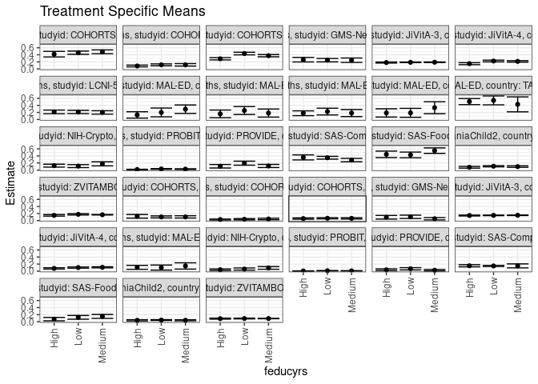

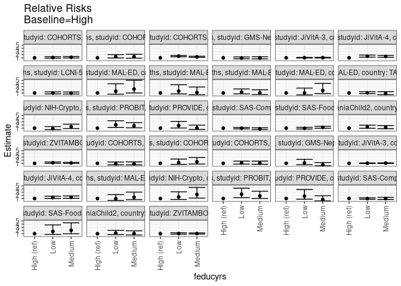

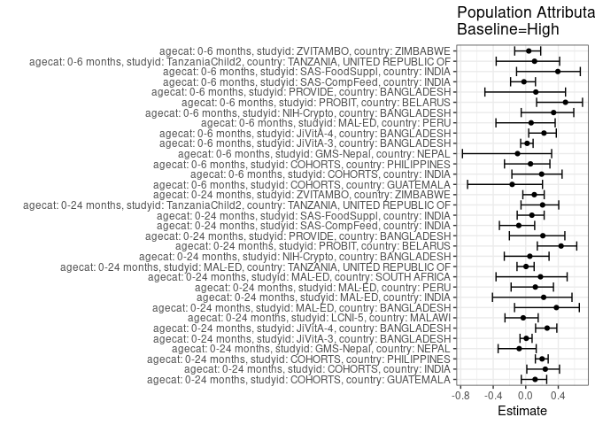

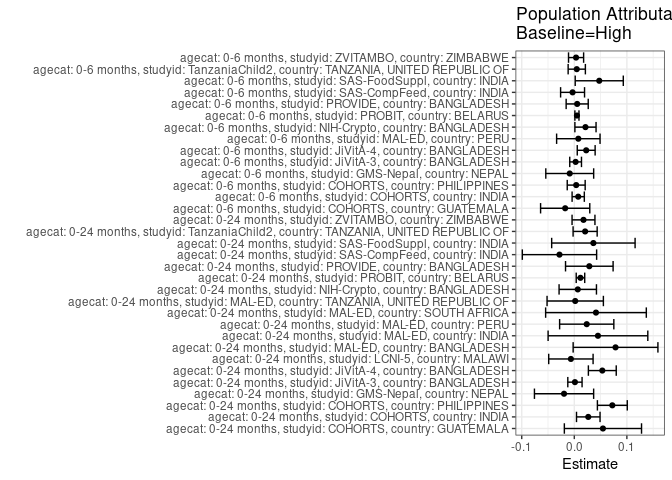

## Results Table

### Parameter: TSM

| agecat | studyid | country | intervention_level | baseline_level | estimate | ci_lower | ci_upper |
| --- | --- | --- | --- | --- | --- | --- | --- |
| 0-24 months | COHORTS | GUATEMALA | High | NA | 0.4183238 | 0.3398426 | 0.4968050 |
| 0-24 months | COHORTS | GUATEMALA | Low | NA | 0.4601186 | 0.4148419 | 0.5053953 |
| 0-24 months | COHORTS | GUATEMALA | Medium | NA | 0.4855930 | 0.4322566 | 0.5389294 |
| 0-24 months | COHORTS | INDIA | High | NA | 0.0839920 | 0.0589549 | 0.1090290 |
| 0-24 months | COHORTS | INDIA | Low | NA | 0.1159066 | 0.0881999 | 0.1436133 |
| 0-24 months | COHORTS | INDIA | Medium | NA | 0.1159165 | 0.0806305 | 0.1512024 |
| 0-24 months | COHORTS | PHILIPPINES | High | NA | 0.2877297 | 0.2556201 | 0.3198393 |
| 0-24 months | COHORTS | PHILIPPINES | Low | NA | 0.4358052 | 0.3989232 | 0.4726872 |
| 0-24 months | COHORTS | PHILIPPINES | Medium | NA | 0.3752898 | 0.3435504 | 0.4070292 |
| 0-24 months | GMS-Nepal | NEPAL | High | NA | 0.2623331 | 0.1982821 | 0.3263842 |
| 0-24 months | GMS-Nepal | NEPAL | Low | NA | 0.2482355 | 0.2002601 | 0.2962109 |
| 0-24 months | GMS-Nepal | NEPAL | Medium | NA | 0.2467611 | 0.1842427 | 0.3092795 |
| 0-24 months | JiVitA-3 | BANGLADESH | High | NA | 0.1816514 | 0.1670531 | 0.1962497 |
| 0-24 months | JiVitA-3 | BANGLADESH | Low | NA | 0.1875211 | 0.1788431 | 0.1961991 |
| 0-24 months | JiVitA-3 | BANGLADESH | Medium | NA | 0.1895715 | 0.1808175 | 0.1983255 |
| 0-24 months | JiVitA-4 | BANGLADESH | High | NA | 0.1491480 | 0.1212713 | 0.1770247 |
| 0-24 months | JiVitA-4 | BANGLADESH | Low | NA | 0.2244281 | 0.1999347 | 0.2489216 |
| 0-24 months | JiVitA-4 | BANGLADESH | Medium | NA | 0.2134298 | 0.1918133 | 0.2350463 |
| 0-24 months | LCNI-5 | MALAWI | High | NA | 0.2143476 | 0.1632777 | 0.2654175 |
| 0-24 months | LCNI-5 | MALAWI | Low | NA | 0.2132010 | 0.1673602 | 0.2590417 |
| 0-24 months | LCNI-5 | MALAWI | Medium | NA | 0.2002418 | 0.1528449 | 0.2476387 |
| 0-24 months | MAL-ED | BANGLADESH | High | NA | 0.1296296 | 0.0397383 | 0.2195209 |
| 0-24 months | MAL-ED | BANGLADESH | Low | NA | 0.2000000 | 0.0756229 | 0.3243771 |
| 0-24 months | MAL-ED | BANGLADESH | Medium | NA | 0.2909091 | 0.1704725 | 0.4113457 |
| 0-24 months | MAL-ED | INDIA | High | NA | 0.1590909 | 0.0506480 | 0.2675338 |
| 0-24 months | MAL-ED | INDIA | Low | NA | 0.2542373 | 0.1427503 | 0.3657243 |
| 0-24 months | MAL-ED | INDIA | Medium | NA | 0.1818182 | 0.0674652 | 0.2961712 |
| 0-24 months | MAL-ED | PERU | High | NA | 0.1763691 | 0.1081283 | 0.2446099 |
| 0-24 months | MAL-ED | PERU | Low | NA | 0.2247478 | 0.1289122 | 0.3205834 |
| 0-24 months | MAL-ED | PERU | Medium | NA | 0.1818958 | 0.0821560 | 0.2816357 |

[output cut: 69 more lines]

### Parameter: E(Y)

| agecat | studyid | country | intervention_level | baseline_level | estimate | ci_lower | ci_upper |
| --- | --- | --- | --- | --- | --- | --- | --- |
| 0-24 months | COHORTS | GUATEMALA | NA | NA | 0.4728000 | 0.4451119 | 0.5004881 |
| 0-24 months | COHORTS | INDIA | NA | NA | 0.1105736 | 0.0944098 | 0.1267374 |
| 0-24 months | COHORTS | PHILIPPINES | NA | NA | 0.3600694 | 0.3425352 | 0.3776037 |
| 0-24 months | GMS-Nepal | NEPAL | NA | NA | 0.2428161 | 0.2109378 | 0.2746944 |
| 0-24 months | JiVitA-3 | BANGLADESH | NA | NA | 0.1828613 | 0.1771578 | 0.1885648 |
| 0-24 months | JiVitA-4 | BANGLADESH | NA | NA | 0.2024261 | 0.1900868 | 0.2147654 |
| 0-24 months | LCNI-5 | MALAWI | NA | NA | 0.2078721 | 0.1799617 | 0.2357825 |
| 0-24 months | MAL-ED | BANGLADESH | NA | NA | 0.2080537 | 0.1426574 | 0.2734499 |
| 0-24 months | MAL-ED | INDIA | NA | NA | 0.2040816 | 0.1387072 | 0.2694561 |
| 0-24 months | MAL-ED | PERU | NA | NA | 0.2000000 | 0.1503169 | 0.2496831 |
| 0-24 months | MAL-ED | SOUTH AFRICA | NA | NA | 0.2272727 | 0.1486005 | 0.3059450 |
| 0-24 months | MAL-ED | TANZANIA, UNITED REPUBLIC OF | NA | NA | 0.5094340 | 0.4419812 | 0.5768867 |
| 0-24 months | NIH-Crypto | BANGLADESH | NA | NA | 0.1306069 | 0.1066024 | 0.1546113 |
| 0-24 months | PROBIT | BELARUS | NA | NA | 0.0269707 | 0.0195564 | 0.0343850 |
| 0-24 months | PROVIDE | BANGLADESH | NA | NA | 0.1357143 | 0.1103250 | 0.1611036 |
| 0-24 months | SAS-CompFeed | INDIA | NA | NA | 0.3300654 | 0.3020915 | 0.3580392 |
| 0-24 months | SAS-FoodSuppl | INDIA | NA | NA | 0.4808612 | 0.4329065 | 0.5288160 |
| 0-24 months | TanzaniaChild2 | TANZANIA, UNITED REPUBLIC OF | NA | NA | 0.0994545 | 0.0874362 | 0.1114727 |
| 0-24 months | ZVITAMBO | ZIMBABWE | NA | NA | 0.1660581 | 0.1598251 | 0.1722911 |
| 0-6 months | COHORTS | GUATEMALA | NA | NA | 0.1039216 | 0.0851851 | 0.1226580 |
| 0-6 months | COHORTS | INDIA | NA | NA | 0.0380014 | 0.0280567 | 0.0479461 |
| 0-6 months | COHORTS | PHILIPPINES | NA | NA | 0.0618056 | 0.0530095 | 0.0706016 |
| 0-6 months | GMS-Nepal | NEPAL | NA | NA | 0.0862069 | 0.0653403 | 0.1070734 |
| 0-6 months | JiVitA-3 | BANGLADESH | NA | NA | 0.1460777 | 0.1409301 | 0.1512254 |
| 0-6 months | JiVitA-4 | BANGLADESH | NA | NA | 0.1008032 | 0.0917342 | 0.1098723 |
| 0-6 months | MAL-ED | PERU | NA | NA | 0.1160000 | 0.0762256 | 0.1557744 |
| 0-6 months | NIH-Crypto | BANGLADESH | NA | NA | 0.0620053 | 0.0448256 | 0.0791849 |
| 0-6 months | PROBIT | BELARUS | NA | NA | 0.0102397 | 0.0068687 | 0.0136108 |
| 0-6 months | PROVIDE | BANGLADESH | NA | NA | 0.0442857 | 0.0290345 | 0.0595370 |
| 0-6 months | SAS-CompFeed | INDIA | NA | NA | 0.1493124 | 0.1303783 | 0.1682465 |
| 0-6 months | SAS-FoodSuppl | INDIA | NA | NA | 0.1201923 | 0.0889059 | 0.1514788 |
| 0-6 months | TanzaniaChild2 | TANZANIA, UNITED REPUBLIC OF | NA | NA | 0.0432228 | 0.0350563 | 0.0513894 |
| 0-6 months | ZVITAMBO | ZIMBABWE | NA | NA | 0.0901382 | 0.0853389 | 0.0949375 |

### Parameter: RR

| agecat | studyid | country | intervention_level | baseline_level | estimate | ci_lower | ci_upper |
| --- | --- | --- | --- | --- | --- | --- | --- |
| 0-24 months | COHORTS | GUATEMALA | High | High | 1.0000000 | 1.0000000 | 1.000000 |
| 0-24 months | COHORTS | GUATEMALA | Low | High | 1.0999103 | 0.8922750 | 1.355863 |
| 0-24 months | COHORTS | GUATEMALA | Medium | High | 1.1608065 | 0.9364003 | 1.438991 |
| 0-24 months | COHORTS | INDIA | High | High | 1.0000000 | 1.0000000 | 1.000000 |
| 0-24 months | COHORTS | INDIA | Low | High | 1.3799721 | 0.9430732 | 2.019274 |
| 0-24 months | COHORTS | INDIA | Medium | High | 1.3800897 | 0.9033311 | 2.108471 |
| 0-24 months | COHORTS | PHILIPPINES | High | High | 1.0000000 | 1.0000000 | 1.000000 |
| 0-24 months | COHORTS | PHILIPPINES | Low | High | 1.5146340 | 1.3194450 | 1.738698 |
| 0-24 months | COHORTS | PHILIPPINES | Medium | High | 1.3043137 | 1.1367711 | 1.496549 |
| 0-24 months | GMS-Nepal | NEPAL | High | High | 1.0000000 | 1.0000000 | 1.000000 |
| 0-24 months | GMS-Nepal | NEPAL | Low | High | 0.9462606 | 0.7003058 | 1.278597 |
| 0-24 months | GMS-Nepal | NEPAL | Medium | High | 0.9406402 | 0.6657751 | 1.328983 |
| 0-24 months | JiVitA-3 | BANGLADESH | High | High | 1.0000000 | 1.0000000 | 1.000000 |
| 0-24 months | JiVitA-3 | BANGLADESH | Low | High | 1.0323133 | 0.9479751 | 1.124155 |
| 0-24 months | JiVitA-3 | BANGLADESH | Medium | High | 1.0436009 | 0.9568535 | 1.138213 |
| 0-24 months | JiVitA-4 | BANGLADESH | High | High | 1.0000000 | 1.0000000 | 1.000000 |
| 0-24 months | JiVitA-4 | BANGLADESH | Low | High | 1.5047346 | 1.2156951 | 1.862495 |
| 0-24 months | JiVitA-4 | BANGLADESH | Medium | High | 1.4309935 | 1.1622517 | 1.761875 |
| 0-24 months | LCNI-5 | MALAWI | High | High | 1.0000000 | 1.0000000 | 1.000000 |
| 0-24 months | LCNI-5 | MALAWI | Low | High | 0.9946504 | 0.7248021 | 1.364965 |
| 0-24 months | LCNI-5 | MALAWI | Medium | High | 0.9341917 | 0.6697218 | 1.303100 |
| 0-24 months | MAL-ED | BANGLADESH | High | High | 1.0000000 | 1.0000000 | 1.000000 |
| 0-24 months | MAL-ED | BANGLADESH | Low | High | 1.5428571 | 0.6078543 | 3.916084 |
| 0-24 months | MAL-ED | BANGLADESH | Medium | High | 2.2441558 | 1.0006999 | 5.032713 |
| 0-24 months | MAL-ED | INDIA | High | High | 1.0000000 | 1.0000000 | 1.000000 |
| 0-24 months | MAL-ED | INDIA | Low | High | 1.5980630 | 0.7105469 | 3.594140 |
| 0-24 months | MAL-ED | INDIA | Medium | High | 1.1428571 | 0.4520604 | 2.889265 |
| 0-24 months | MAL-ED | PERU | High | High | 1.0000000 | 1.0000000 | 1.000000 |
| 0-24 months | MAL-ED | PERU | Low | High | 1.2743038 | 0.7153831 | 2.269903 |
| 0-24 months | MAL-ED | PERU | Medium | High | 1.0313362 | 0.5285076 | 2.012562 |

[output cut: 69 more lines]

### Parameter: PAR

| agecat | studyid | country | intervention_level | baseline_level | estimate | ci_lower | ci_upper |
| --- | --- | --- | --- | --- | --- | --- | --- |
| 0-24 months | COHORTS | GUATEMALA | High | NA | 0.0544762 | -0.0189310 | 0.1278834 |
| 0-24 months | COHORTS | INDIA | High | NA | 0.0265816 | 0.0041947 | 0.0489685 |
| 0-24 months | COHORTS | PHILIPPINES | High | NA | 0.0723397 | 0.0439263 | 0.1007531 |
| 0-24 months | GMS-Nepal | NEPAL | High | NA | -0.0195170 | -0.0758214 | 0.0367873 |
| 0-24 months | JiVitA-3 | BANGLADESH | High | NA | 0.0012099 | -0.0123580 | 0.0147778 |
| 0-24 months | JiVitA-4 | BANGLADESH | High | NA | 0.0532781 | 0.0267824 | 0.0797738 |
| 0-24 months | LCNI-5 | MALAWI | High | NA | -0.0064756 | -0.0486807 | 0.0357296 |
| 0-24 months | MAL-ED | BANGLADESH | High | NA | 0.0784241 | -0.0021994 | 0.1590476 |
| 0-24 months | MAL-ED | INDIA | High | NA | 0.0449907 | -0.0498447 | 0.1398262 |
| 0-24 months | MAL-ED | PERU | High | NA | 0.0236309 | -0.0279306 | 0.0751925 |
| 0-24 months | MAL-ED | SOUTH AFRICA | High | NA | 0.0412262 | -0.0545238 | 0.1369763 |
| 0-24 months | MAL-ED | TANZANIA, UNITED REPUBLIC OF | High | NA | 0.0017417 | -0.0518281 | 0.0553114 |
| 0-24 months | NIH-Crypto | BANGLADESH | High | NA | 0.0065887 | -0.0289671 | 0.0421445 |
| 0-24 months | PROBIT | BELARUS | High | NA | 0.0117241 | 0.0036413 | 0.0198069 |
| 0-24 months | PROVIDE | BANGLADESH | High | NA | 0.0285604 | -0.0166836 | 0.0738043 |
| 0-24 months | SAS-CompFeed | INDIA | High | NA | -0.0282084 | -0.0988878 | 0.0424710 |
| 0-24 months | SAS-FoodSuppl | INDIA | High | NA | 0.0362945 | -0.0430453 | 0.1156343 |
| 0-24 months | TanzaniaChild2 | TANZANIA, UNITED REPUBLIC OF | High | NA | 0.0205910 | -0.0023002 | 0.0434821 |
| 0-24 months | ZVITAMBO | ZIMBABWE | High | NA | 0.0174943 | -0.0042629 | 0.0392516 |
| 0-6 months | COHORTS | GUATEMALA | High | NA | -0.0173521 | -0.0641369 | 0.0294327 |
| 0-6 months | COHORTS | INDIA | High | NA | 0.0074283 | -0.0041923 | 0.0190490 |
| 0-6 months | COHORTS | PHILIPPINES | High | NA | 0.0036142 | -0.0134392 | 0.0206677 |
| 0-6 months | GMS-Nepal | NEPAL | High | NA | -0.0086979 | -0.0542249 | 0.0368291 |
| 0-6 months | JiVitA-3 | BANGLADESH | High | NA | 0.0024955 | -0.0086704 | 0.0136614 |
| 0-6 months | JiVitA-4 | BANGLADESH | High | NA | 0.0226247 | 0.0056272 | 0.0396222 |
| 0-6 months | MAL-ED | PERU | High | NA | 0.0076667 | -0.0336394 | 0.0489727 |
| 0-6 months | NIH-Crypto | BANGLADESH | High | NA | 0.0212487 | 0.0011283 | 0.0413690 |
| 0-6 months | PROBIT | BELARUS | High | NA | 0.0050047 | 0.0011191 | 0.0088904 |
| 0-6 months | PROVIDE | BANGLADESH | High | NA | 0.0054926 | -0.0155087 | 0.0264940 |
| 0-6 months | SAS-CompFeed | INDIA | High | NA | -0.0032900 | -0.0260624 | 0.0194823 |
| 0-6 months | SAS-FoodSuppl | INDIA | High | NA | 0.0474650 | 0.0017362 | 0.0931939 |
| 0-6 months | TanzaniaChild2 | TANZANIA, UNITED REPUBLIC OF | High | NA | 0.0046750 | -0.0117191 | 0.0210691 |
| 0-6 months | ZVITAMBO | ZIMBABWE | High | NA | 0.0033642 | -0.0109899 | 0.0177183 |

### Parameter: PAF

| agecat | studyid | country | intervention_level | baseline_level | estimate | ci_lower | ci_upper |
| --- | --- | --- | --- | --- | --- | --- | --- |
| 0-24 months | COHORTS | GUATEMALA | High | NA | 0.1152204 | -0.0546783 | 0.2577501 |
| 0-24 months | COHORTS | INDIA | High | NA | 0.2403974 | 0.0130323 | 0.4153851 |
| 0-24 months | COHORTS | PHILIPPINES | High | NA | 0.2009050 | 0.1182048 | 0.2758490 |
| 0-24 months | GMS-Nepal | NEPAL | High | NA | -0.0803779 | -0.3396252 | 0.1286993 |
| 0-24 months | JiVitA-3 | BANGLADESH | High | NA | 0.0066166 | -0.0704176 | 0.0781069 |
| 0-24 months | JiVitA-4 | BANGLADESH | High | NA | 0.2631978 | 0.1210512 | 0.3823559 |
| 0-24 months | LCNI-5 | MALAWI | High | NA | -0.0311516 | -0.2555026 | 0.1531091 |
| 0-24 months | MAL-ED | BANGLADESH | High | NA | 0.3769415 | -0.1376520 | 0.6587692 |
| 0-24 months | MAL-ED | INDIA | High | NA | 0.2204545 | -0.4090534 | 0.5687239 |
| 0-24 months | MAL-ED | PERU | High | NA | 0.1181546 | -0.1799235 | 0.3409307 |
| 0-24 months | MAL-ED | SOUTH AFRICA | High | NA | 0.1813953 | -0.3655131 | 0.5092588 |
| 0-24 months | MAL-ED | TANZANIA, UNITED REPUBLIC OF | High | NA | 0.0034188 | -0.1074860 | 0.1032175 |
| 0-24 months | NIH-Crypto | BANGLADESH | High | NA | 0.0504466 | -0.2640383 | 0.2866896 |
| 0-24 months | PROBIT | BELARUS | High | NA | 0.4346983 | 0.1423608 | 0.6273888 |
| 0-24 months | PROVIDE | BANGLADESH | High | NA | 0.2104450 | -0.2011428 | 0.4809966 |
| 0-24 months | SAS-CompFeed | INDIA | High | NA | -0.0854630 | -0.3238439 | 0.1099933 |
| 0-24 months | SAS-FoodSuppl | INDIA | High | NA | 0.0754781 | -0.1052606 | 0.2266614 |
| 0-24 months | TanzaniaChild2 | TANZANIA, UNITED REPUBLIC OF | High | NA | 0.2070393 | -0.0583114 | 0.4058585 |
| 0-24 months | ZVITAMBO | ZIMBABWE | High | NA | 0.1053508 | -0.0356334 | 0.2271423 |
| 0-6 months | COHORTS | GUATEMALA | High | NA | -0.1669732 | -0.7155313 | 0.2061781 |
| 0-6 months | COHORTS | INDIA | High | NA | 0.1954748 | -0.1705162 | 0.4470296 |
| 0-6 months | COHORTS | PHILIPPINES | High | NA | 0.0584777 | -0.2614082 | 0.2972423 |
| 0-6 months | GMS-Nepal | NEPAL | High | NA | -0.1008954 | -0.7782826 | 0.3184600 |
| 0-6 months | JiVitA-3 | BANGLADESH | High | NA | 0.0170832 | -0.0623837 | 0.0906059 |
| 0-6 months | JiVitA-4 | BANGLADESH | High | NA | 0.2244441 | 0.0365757 | 0.3756779 |
| 0-6 months | MAL-ED | PERU | High | NA | 0.0660920 | -0.3666002 | 0.3617854 |
| 0-6 months | NIH-Crypto | BANGLADESH | High | NA | 0.3426915 | -0.0558471 | 0.5907983 |
| 0-6 months | PROBIT | BELARUS | High | NA | 0.4887559 | 0.1335658 | 0.6983377 |
| 0-6 months | PROVIDE | BANGLADESH | High | NA | 0.1240267 | -0.5021944 | 0.4891945 |
| 0-6 months | SAS-CompFeed | INDIA | High | NA | -0.0220346 | -0.1863958 | 0.1195563 |
| 0-6 months | SAS-FoodSuppl | INDIA | High | NA | 0.3949091 | -0.1128652 | 0.6709979 |
| 0-6 months | TanzaniaChild2 | TANZANIA, UNITED REPUBLIC OF | High | NA | 0.1081600 | -0.3637228 | 0.4167593 |
| 0-6 months | ZVITAMBO | ZIMBABWE | High | NA | 0.0373227 | -0.1358258 | 0.1840759 |